# 2026-05-11_Ssd1_pointmutant_flow

Benny Kleinerman

2026-05-11

# Summary

Summary: Analysis of the flow cytometry data gathered 2026-02-17, on episomal Ssd1 RNA-binding point mutants, in a Sun4-mNeonGreen reporter background.

This script only includes code to generate figures for the paper. Additional code is in 2026-02-17_Ssd1_pm_redo or similar scripts.

# Define functions to load flow cytometry data, using FlowCore package

```r
repair_flow_colnames <- function(string) {
  string %>%
    stringr::str_replace_all(" ", "") %>%
    stringr::str_replace_all("PE-", "PE") %>%
    stringr::str_replace_all("-", "_")
}

read_fcs_tibble <- function(file,...) {
  read.FCS(file,...) %>%
    .@exprs %>%
    as_tibble %>%
    set_names(repair_flow_colnames(names(.)))
}
```

# Describe the data

First we load the sample sheet, that describes the sample contents and filenames.

```r
datadir <- here::here("2026-02-17_Ssd1_pm_redo")

samplesheet <- paste(datadir, "/2026-02-17_Ssd1_pm_redo_plan.xlsx", sep = "") %>%
  readxl::read_excel(skip = 4) %>%
  mutate(Biorep = factor(Biorep))

print(samplesheet, n = 19)
```

```
## # A tibble: 24 × 13
##    Sample ID       Biorep Promoter SSD1_homolog_unstruc…¹ SSD1_homolog_structu…²
##     <dbl> <chr>    <fct>  <chr>    <chr>                  <chr>
##  1      1 yBK035   1      RNR2     Saccharomyces cerevis… Saccharomyces cerevis…
##  2      2 yBK035   2      RNR2     Saccharomyces cerevis… Saccharomyces cerevis…
##  3      3 yBK035   3      RNR2     Saccharomyces cerevis… Saccharomyces cerevis…
##  4      4 yBK039   1      NA       NA                     NA
##  5      5 yBK039   2      NA       NA                     NA
##  6      6 yBK039   3      NA       NA                     NA
##  7      7 yBK049   1      RNR2     NA                     NA
##  8      8 yBK049   2      RNR2     NA                     NA
##  9      9 yBK049   3      RNR2     NA                     NA
## 10     10 pRNR2-S… 1      RNR2     Saccharomyces cerevis… Saccharomyces cerevis…
## 11     11 pRNR2-S… 2      RNR2     Saccharomyces cerevis… Saccharomyces cerevis…
## 12     12 pRNR2-S… 3      RNR2     Saccharomyces cerevis… Saccharomyces cerevis…
## 13     13 pRNR2-S… 1      RNR2     Saccharomyces cerevis… Saccharomyces cerevis…
## 14     14 pRNR2-S… 2      RNR2     Saccharomyces cerevis… Saccharomyces cerevis…
## 15     15 pRNR2-S… 3      RNR2     Saccharomyces cerevis… Saccharomyces cerevis…
## 16     16 pRNR2-S… 1      RNR2     Saccharomyces cerevis… Saccharomyces cerevis…
## 17     17 pRNR2-S… 2      RNR2     Saccharomyces cerevis… Saccharomyces cerevis…
## 18     18 pRNR2-S… 3      RNR2     Saccharomyces cerevis… Saccharomyces cerevis…
## 19     19 pRNR2-S… 1      RNR2     Saccharomyces cerevis… Saccharomyces cerevis…
## # ℹ 5 more rows
## # ℹ abbreviated names: ¹SSD1_homolog_unstructured, ²SSD1_homolog_structured
## # ℹ 7 more variables: Expression <chr>, mRuby2 <chr>, SUN4_mNeonGreen <chr>,
## #   Culture_media <chr>, Strain <chr>, Experiment <chr>, Filename <chr>
```

# Load all the data

Next we load the data from all those files.

```r
flow_data_all <- samplesheet  %>%
  group_by(Sample, ID, Biorep, SSD1_homolog_unstructured, SSD1_homolog_structured, Expression, mRuby2, Culture_media, Strain, Experiment, Filename) %>%
  do( read_fcs_tibble(paste(datadir, .$Filename[1], sep = "/")) )
```

# Gate data

Gates for other populations are in the older scripts, described in the Summary

```r
# Gate containing budded singlet cells, as identified by imaging flow cytometry
flow_data_gated_buddedsinglets <- flow_data_all %>%
  dplyr::filter(FSC_H > 30000, FSC_H < 60000,
                FSC_W > 66000, FSC_W < 72000)
```

# How many events remain after gating?

```r
flow_data_all
```

```
## # A tibble: 499,670 × 20
## # Groups:   Sample, ID, Biorep, SSD1_homolog_unstructured,
## #   SSD1_homolog_structured, Expression, mRuby2, Culture_media, Strain,
## #   Experiment, Filename [24]
##    Sample ID     Biorep SSD1_homolog_unstruc…¹ SSD1_homolog_structu…² Expression
##     <dbl> <chr>  <fct>  <chr>                  <chr>                  <chr>
##  1      1 yBK035 1      Saccharomyces cerevis… Saccharomyces cerevis… Plasmid
##  2      1 yBK035 1      Saccharomyces cerevis… Saccharomyces cerevis… Plasmid
##  3      1 yBK035 1      Saccharomyces cerevis… Saccharomyces cerevis… Plasmid
##  4      1 yBK035 1      Saccharomyces cerevis… Saccharomyces cerevis… Plasmid
##  5      1 yBK035 1      Saccharomyces cerevis… Saccharomyces cerevis… Plasmid
##  6      1 yBK035 1      Saccharomyces cerevis… Saccharomyces cerevis… Plasmid
##  7      1 yBK035 1      Saccharomyces cerevis… Saccharomyces cerevis… Plasmid
##  8      1 yBK035 1      Saccharomyces cerevis… Saccharomyces cerevis… Plasmid
##  9      1 yBK035 1      Saccharomyces cerevis… Saccharomyces cerevis… Plasmid
## 10      1 yBK035 1      Saccharomyces cerevis… Saccharomyces cerevis… Plasmid
## # ℹ 499,660 more rows
## # ℹ abbreviated names: ¹SSD1_homolog_unstructured, ²SSD1_homolog_structured
## # ℹ 14 more variables: mRuby2 <chr>, Culture_media <chr>, Strain <chr>,
## #   Experiment <chr>, Filename <chr>, FSC_A <dbl>, FSC_H <dbl>, FSC_W <dbl>,
## #   SSC_A <dbl>, SSC_H <dbl>, SSC_W <dbl>, `530_30(488)_A` <dbl>,
## #   `610_20(561)_A` <dbl>, Time <dbl>
```

```r
flow_count_gates <-
  left_join(flow_data_all %>%
              group_by(Filename) %>%
              tally(),
            flow_data_gated_buddedsinglets %>%
              group_by(Filename) %>%
              tally(),
            by = c("Filename"),
            suffix = c("_all", "_gated") ) %>%
  mutate(prop_gated = n_gated / n_all)

print(flow_count_gates, n = 19)
```

```
## # A tibble: 24 × 4
##    Filename                     n_all n_gated prop_gated
##    <chr>                        <int>   <int>      <dbl>
##  1 Specimen_001_A10_A10_010.fcs 20760    3753      0.181
##  2 Specimen_001_A11_A11_011.fcs 20540    3861      0.188
##  3 Specimen_001_A12_A12_012.fcs 20625    3725      0.181
##  4 Specimen_001_A1_A01_001.fcs  21381    4405      0.206
##  5 Specimen_001_A2_A02_002.fcs  20687    4535      0.219
##  6 Specimen_001_A3_A03_003.fcs  20529    4482      0.218
##  7 Specimen_001_A4_A04_004.fcs  21027    2959      0.141
##  8 Specimen_001_A5_A05_005.fcs  20977    3100      0.148
##  9 Specimen_001_A6_A06_006.fcs  20910    2993      0.143
## 10 Specimen_001_A7_A07_007.fcs  20831    3310      0.159
## 11 Specimen_001_A8_A08_008.fcs  21283    3005      0.141
## 12 Specimen_001_A9_A09_009.fcs  20880    3160      0.151
## 13 Specimen_001_B10_B10_022.fcs 21027    2542      0.121
## 14 Specimen_001_B11_B11_023.fcs 20962    2650      0.126
## 15 Specimen_001_B12_B12_024.fcs 20918    3241      0.155
## 16 Specimen_001_B1_B01_013.fcs  20999    3190      0.152
## 17 Specimen_001_B2_B02_014.fcs  20937    3073      0.147
## 18 Specimen_001_B3_B03_015.fcs  21085    3010      0.143
## 19 Specimen_001_B4_B04_016.fcs  20594    4734      0.230
## # ℹ 5 more rows
```

Samples still have thousands of events after gating

# Compare mNeonGreen (FITC) signal with FSC_A (forward scatter area)

## mRuby2 control (ssd1Δ)

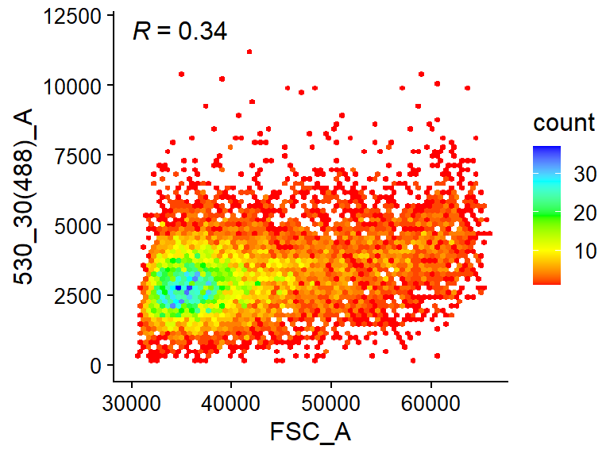

```r
ggplot(
  data = dplyr::filter(flow_data_gated_buddedsinglets, Strain == "dual stain"),
  aes(x = FSC_A, y = `530_30(488)_A`)) +
  geom_hex(bins = 64) +
  scale_fill_gradientn(colours = rainbow(6)[1:5]) +
  stat_cor(
    method = "pearson",
    aes(label = ..r.label..),
    label.sep = "",
    r.accuracy = 0.01,
    label.x = 30000,
    label.y = 12000) +
  ylim(c(0, 12000))
```

## WT

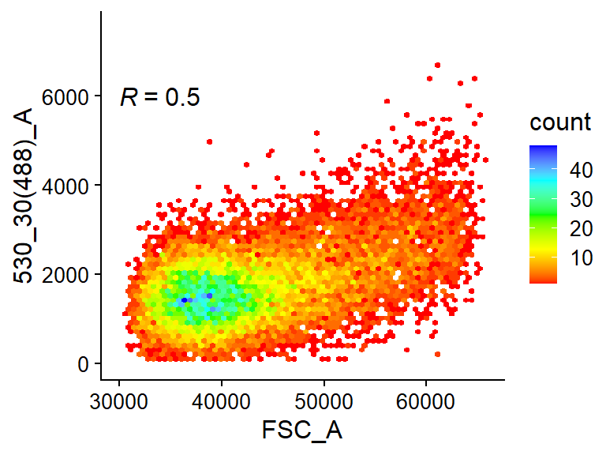

```r
ggplot(
  data = dplyr::filter(flow_data_gated_buddedsinglets, Strain == "pRNR2-ScSSD1-mRuby2"),
  aes(x = FSC_A, y = `530_30(488)_A`)) +
  geom_hex(bins = 64) +
  scale_fill_gradientn(colours = rainbow(6)[1:5]) +
  stat_cor(
    method = "pearson",
    aes(label = ..r.label..),
    label.sep = "",
    r.accuracy = 0.01,
    label.x = 30000,
    label.y = 6000) +
  ylim(c(0, 7500))
```

mNeonGreen scales with FSC_A, at least for these 2 strains

# Ridgeplots of mNeonGreen for ssd1 point mutant strains

## First create a new column in the budded singlets dataset, with readable Strain names

```r
flow_data_gated_buddedsinglets <- flow_data_gated_buddedsinglets %>%
  mutate(ssd1locus = forcats::fct_recode(Strain,
      "WT" = "pRNR2-ScSSD1-mRuby2",
      "Empty" = "ssd1Δ",
      "Empty mRuby2" = "dual stain",
      "R394A" = "pRNR2-Scssd1R394A-mRuby2",
      "W583A" = "pRNR2-Scssd1W583A-mRuby2",
      "K589A" = "pRNR2-Scssd1K589A-mRuby2",
      "KR622-623AA" = "pRNR2-Scssd1KR622-623AA-mRuby2",
      "H630A" = "pRNR2-Scssd1H630A-mRuby2"),
    ssd1locus = fct_rev(ssd1locus))
```

## SUN4-mNeonGreen, with FSC normalization

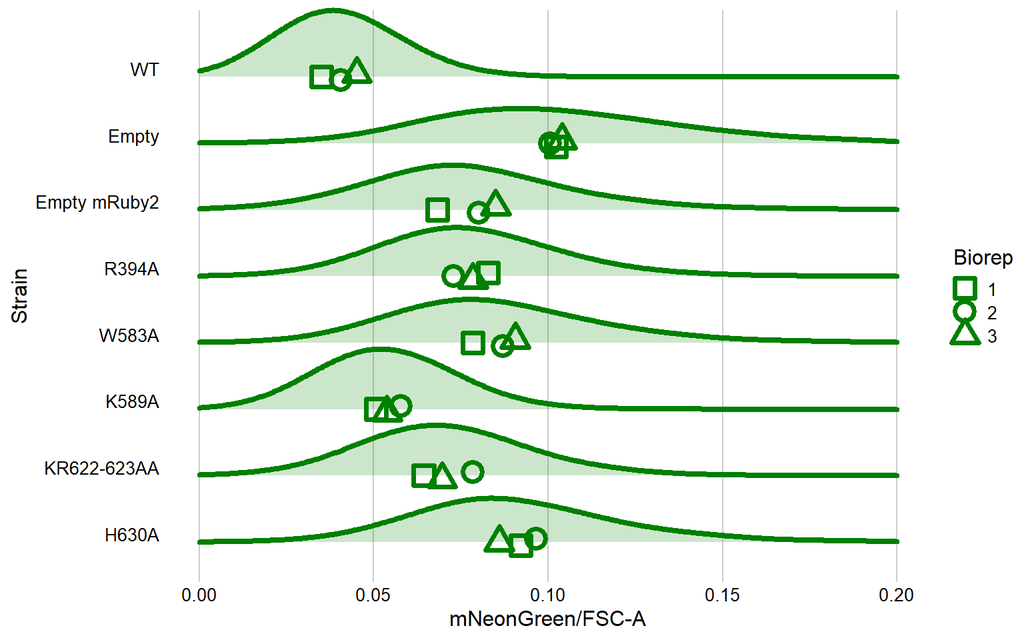

```r
mNG <- ggplot(
  data = flow_data_gated_buddedsinglets,
  aes(x = `530_30(488)_A` / FSC_A, y = ssd1locus)) +
  stat_density_ridges(
    scale = 1,
    linewidth = 1.5,
    alpha = 0.2,
    colour = "#008000ff",
    fill = "#008000ff",
    bandwidth = 0.01) +
  stat_summary(
    aes(group = interaction(Strain, Biorep), shape = Biorep),
    colour = "#008000ff",
    fun = mean,
    geom = "point",
    size = 4,
    stroke = 2,
    position = position_quasirandom(groupOnX = FALSE, width = 0.1)) +
  labs(x = "mNeonGreen/FSC-A", y = "Strain") +
  theme(
    panel.grid.major.x = element_line(colour = "grey80"),
    axis.line = element_blank(),
    axis.ticks = element_blank(),
    axis.text.y = element_text(vjust = -0.1)) +
  coord_cartesian(expand = TRUE, clip = 'off') +
  scale_x_continuous(limits = c(0, 0.2)) +
  scale_shape_manual(values = c(0, 1, 2))

mNG
```

```r
# I manually annotate axis labels and legends in inkscape

ggsave(
  filename = "U:/data/2026/05-May/Benny/2026-05-11_Ssd1_pointmutants_mNG_flow.svg",
  plot = mNG,
  device = "svg",
  width = 10,
  height = 10,
  limitsize = FALSE)
```

Generally, RNA-binding Ssd1 point mutants fail to regulate Sun4-mNeonGreen expression. The exception to this is the K589A mutant

## Ssd1-mRuby2

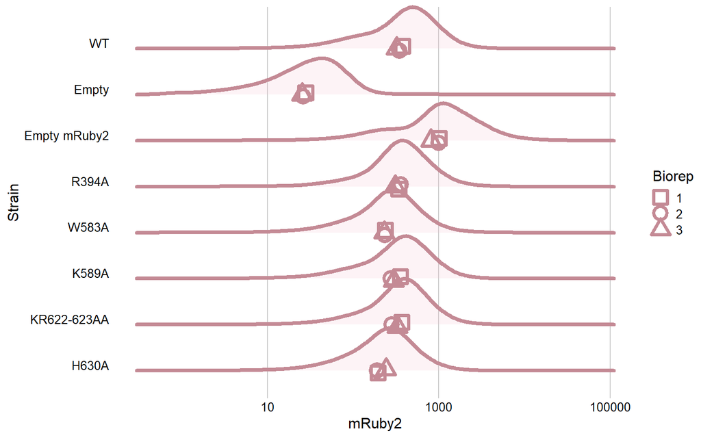

```r
mRuby2 <- ggplot(dplyr::filter(
  flow_data_gated_buddedsinglets, `610_20(561)_A` > 0),
  aes(x = `610_20(561)_A`, y = ssd1locus)) +
  stat_density_ridges(
    scale = 1,
    linewidth = 1.5,
    alpha = 0.2,
    bandwidth = 0.15,
    colour = "#C48A95",
    fill = "#F6C1D1") +
  stat_summary(
    aes(group = interaction(Strain, Biorep), shape = Biorep),
    fun = mean,
    geom = "point",
    size = 4,
    stroke = 2,
    colour = "#C48A95",
    position = position_quasirandom(groupOnX = FALSE, width = 0.1)) +
  labs(x = "mRuby2", y = "Strain") +
  theme(
    panel.grid.major.x = element_line(colour = "grey80"),
    axis.line = element_blank(),
    axis.ticks = element_blank(),
    axis.text.y = element_text(vjust = -0.1)) +
  coord_cartesian(expand = TRUE, clip = 'off') +
  scale_x_log10(breaks = c(10, 1000, 100000),
    labels = c("10", "1000", "100000")) +
  scale_colour_manual(values = c("#C48A95")) +
  scale_fill_manual(values = c("#F6C1D1")) +
  scale_shape_manual(values = c(0, 1, 2))

mRuby2
```

```r
# I manually annotate axis labels and legends in inkscape

ggsave(
  filename = "U:/data/2026/05-May/Benny/2026-03-14_Ssd1_pointmutant_mRuby2_flow.svg",
  plot = mRuby2,
  device = "svg",
  width = 10,
  height = 10,
  limitsize = FALSE)
```

All point mutants are expressing from plasmids under pRNR2. Translational repression aligns well with growth on CFW

# Calculate fold changes between the strain means

## mRuby2, comparing all strains to the empty plasmid strain

```r
# Set Empty plasmid strain as the reference

flow_data_gated_buddedsinglets_emptyref <- flow_data_gated_buddedsinglets %>%
  dplyr::filter(`610_20(561)_A` > 0) %>%
  dplyr::ungroup() %>%
  dplyr::mutate(ssd1locus = relevel(as.factor(ssd1locus), ref = "Empty"))

# log10 linear model

fit_mRuby2 <- lm(
  log10(`610_20(561)_A`) ~ ssd1locus,
  data = flow_data_gated_buddedsinglets_emptyref)

foldchange_mRuby2 <- 10^{ coef(fit_mRuby2)[-1] }
foldchange_mRuby2
```

```
##        ssd1locusH630A  ssd1locusKR622-623AA        ssd1locusK589A
##              7.971268             12.304651             11.727663
##        ssd1locusW583A        ssd1locusR394A ssd1locusEmpty mRuby2
##              8.900649             12.780031             35.390136
##           ssd1locusWT
##             13.155616
```

The empty mRuby2 construct (no Ssd1) produces 35 times as much red signal as background in an mRuby2-less strain, and the constructs with Ssd1 produce ~10 times as much red signal

## mNeonGreen, comparing all strains to wild-type Ssd1

```r
# Set WT Ssd1 strain as the reference

flow_data_gated_buddedsinglets_WTref <- flow_data_gated_buddedsinglets %>%
  dplyr::filter(`530_30(488)_A` > 0) %>%
  dplyr::ungroup() %>%
  dplyr::mutate(ssd1locus = relevel(as.factor(ssd1locus), ref = "WT"))

# linear model

fit_mNG <- lm(
  log10(`530_30(488)_A`/FSC_A) ~ ssd1locus,
  data = flow_data_gated_buddedsinglets_WTref)

foldchange_mNG <- 10^{ coef(fit_mNG)[-1] }
foldchange_mNG
```

```
##        ssd1locusH630A  ssd1locusKR622-623AA        ssd1locusK589A
##              2.373909              1.820857              1.387153
##        ssd1locusW583A        ssd1locusR394A ssd1locusEmpty mRuby2
##              2.209058              2.017178              1.954850
##        ssd1locusEmpty
##              2.721430
```

There is 2.72 times as much mNeonGreen in ssd1 deletion cells as Wild Type Ssd1